# Projekt na 4

Filip Żabicki

21.02.2021

## a)

### Przygotowanie danych oraz bibliotek

```r
set.seed(1337)
library(agricolae)
library(ggplot2)
library(MASS)
library(nnet)
library(caret)
library(glmnet)
library(klaR)
library(tidyverse)
library(tidyr)

data(yacon)
yacon <- yacon[, c("locality", "wfr", "fructose", "sucrose", "dry")]

summary(yacon)
```

```
##  locality       wfr           fructose         sucrose           dry
##  CAJ:144   Min.   :  200   Min.   : 1.500   Min.   :-1.36   Min.   : 5.60
##  LIM:144   1st Qu.: 5460   1st Qu.: 6.525   1st Qu.:12.86   1st Qu.:12.60
##  OXA:144   Median :10515   Median :14.975   Median :18.67   Median :17.40
##            Mean   :19962   Mean   :17.824   Mean   :18.07   Mean   :17.49
##            3rd Qu.:31855   3rd Qu.:28.087   3rd Qu.:24.05   3rd Qu.:21.52
##            Max.   :87450   Max.   :54.150   Max.   :37.30   Max.   :42.00
```

Podsumowanie danych

```r
head(yacon)
```

|  | locality | wfr | fructose | sucrose | dry |
| --- | --- | --- | --- | --- | --- |
| 1 | CAJ | 6700 | 5.0 | 26.66 | 15.6 |
| 2 | CAJ | 6450 | 4.5 | 28.84 | 17.0 |
| 3 | CAJ | 7550 | 9.3 | 27.06 | 15.9 |
| 4 | CAJ | 4120 | 8.1 | 25.60 | 13.7 |
| 5 | CAJ | 7150 | 10.6 | 27.90 | 14.5 |
| 6 | CAJ | 7520 | 13.1 | 27.20 | 15.1 |

Pierwszych kilka wierszy danych

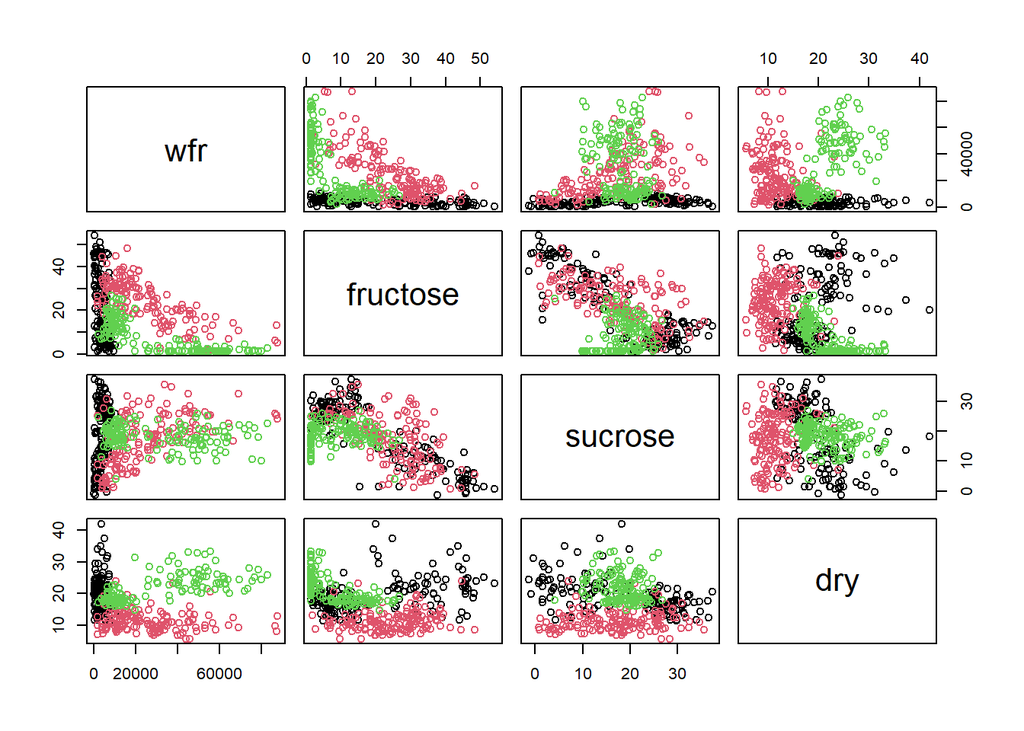

```r
pairs(yacon[, -1], col = yacon$locality)
```

Wykresy rozrzutu zmiennych, kolorem zaznaczono klasy zmiennej objaśnianej. Zestawienia wfr+fructose oraz dry+wfr wydają się mieć duży potencjał do użycia w celu klasyfikacji.

Nie ma brakujących danych i wyglądają one sensownie, są gotowe do użycia w modelu.

### Model klasyfikacji metodą LDA

Zbudujemy model LDA dla dwóch pierwszych zmiennych kanonicznych i stworzymy wykres z obszarami klasyfikacji.

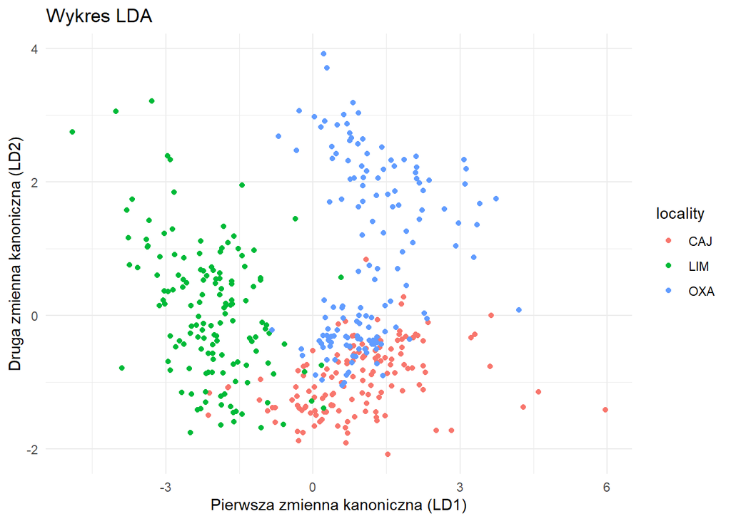

```r
# LDA model
lda_model <- lda(locality ~ wfr + fructose + sucrose + dry, data = yacon)
lda_pred <- predict(lda_model)

# Przekształcenie macierzy na ramkę danych
lda_pred_df <- as.data.frame(lda_pred$x)

# Dodanie kolumny ze zmienną objaśnianą do ramki danych
lda_pred_df$locality <- yacon$locality


ggplot(lda_pred_df, aes(x = LD1, y = LD2, color = locality)) +
  geom_point() +
  theme_minimal() +
  labs(title = "Wykres LDA",
       x = "Pierwsza zmienna kanoniczna (LD1)",
       y ="Druga zmienna kanoniczna (LD2)")
```

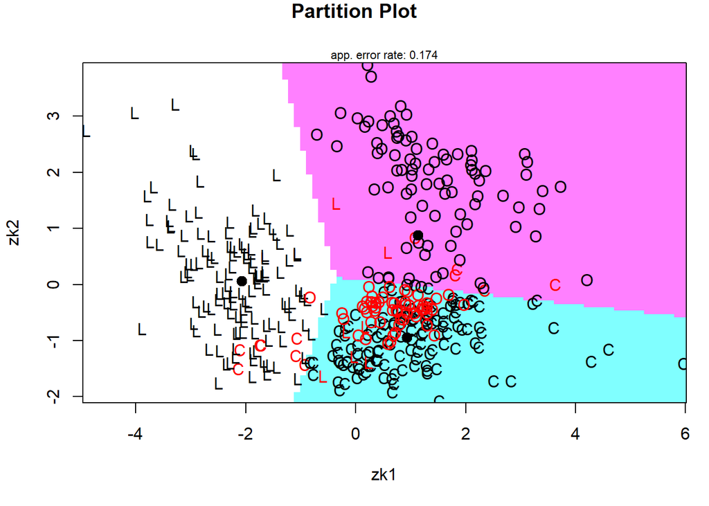

```r
zk1 <- lda_pred$x[,1]
zk2 <- lda_pred$x[,2]
partimat(locality~zk2+zk1,
         data=yacon)
```

### Sprawdzenie jakości modelu LDA

Użyję to tego macierzy pomyłek oraz sprawdzę dokładność.

```r
# Predykcja modelu LDA
lda_pred <- predict(lda_model, yacon)

# Macierz pomyłek
confusionMatrix <- table(Observed = yacon$locality, Predicted = lda_pred$class)
print(confusionMatrix)
```

```
##         Predicted
## Observed CAJ LIM OXA
##      CAJ 132   7   5
##      LIM   5 137   2
##      OXA  55   1  88
```

```r
# Obliczenie dokładności
accuracy <- sum(diag(confusionMatrix)) / sum(confusionMatrix)
print(paste("Dokładność: ", accuracy))
```

```
## [1] "Dokładność:  0.826388888888889"
```

## b)

### Model klasyfikacji oparty na regresji logistycznej z karą

#### Budowa modelu z pakietu glmnet

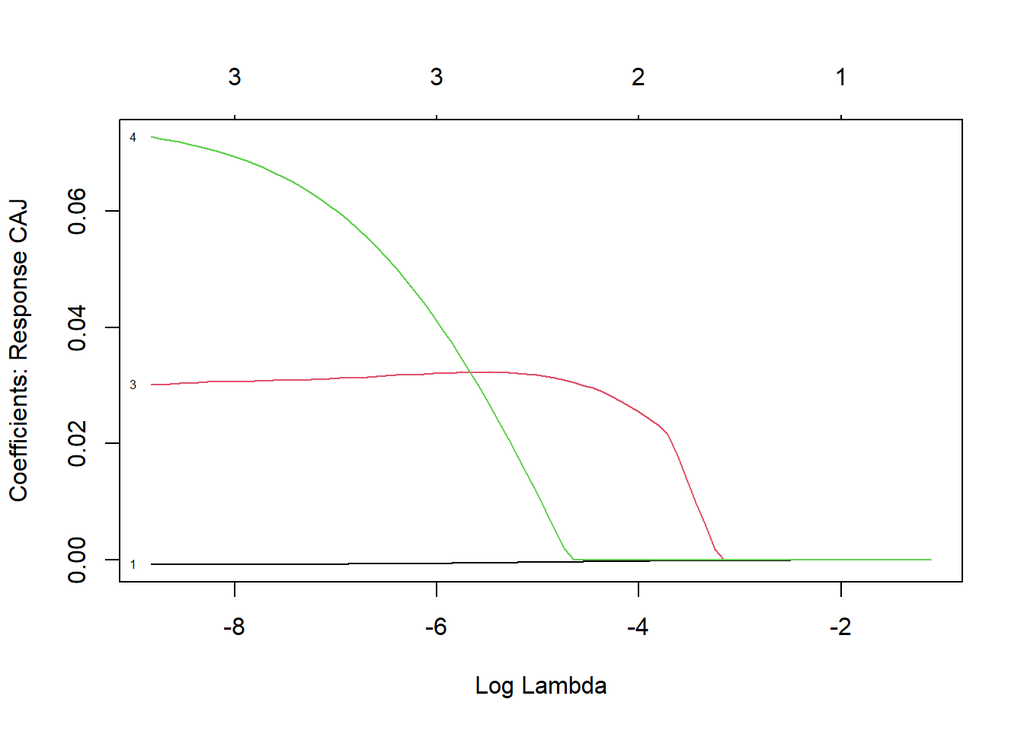

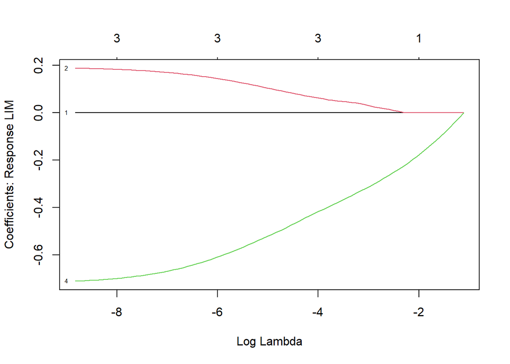

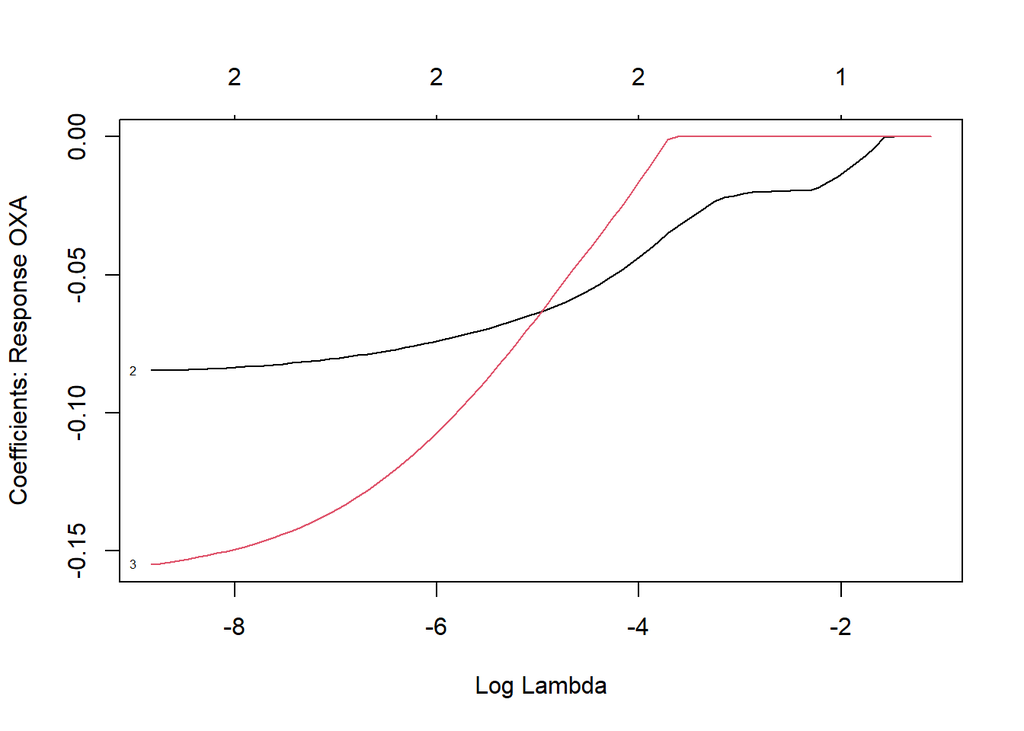

```r
logit_model <- glmnet(as.matrix(yacon[, -1]),
                      yacon$locality,
                      family = "multinomial")
plot(logit_model, xvar = "lambda", label = TRUE)
```

Wykresy pozwalają zobaczyć, jak zmieniają się współczynniki modelu w zależności od wartości parametru lambda, który kontroluje siłę regularyzacji.

#### Szukanie najlepszych parametrów funkcji kary

10-krotna kroswalidacja

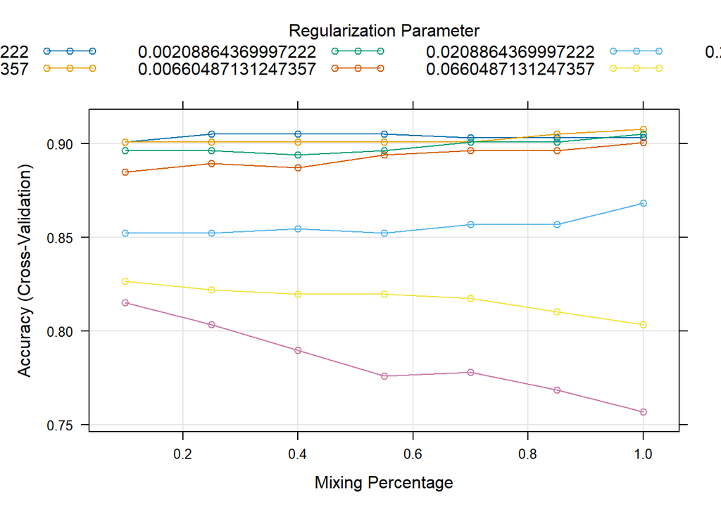

```r
 # 10-krotna
logistic_10 <- train(locality ~ wfr + fructose + sucrose + dry,
                    data = yacon,
                    method = "glmnet",
                    trControl = trainControl(method = "cv"),
                    tuneLength=7
                    #tuneGrid=data.frame(alpha=c(0,0.5,1),lambda=c(1,0.1,0.01,0.001,0.0001,0.00001,0))
                    )
plot(logistic_10)
```

```r
print(logistic_10$bestTune)
```

```
##    alpha       lambda
## 44     1 0.0006604871
```

```r
print(logistic_10$results[row.names(logistic_10$bestTune), "Accuracy"])
```

```
## [1] 0.9077326
```

n-krotna kroswalidacja

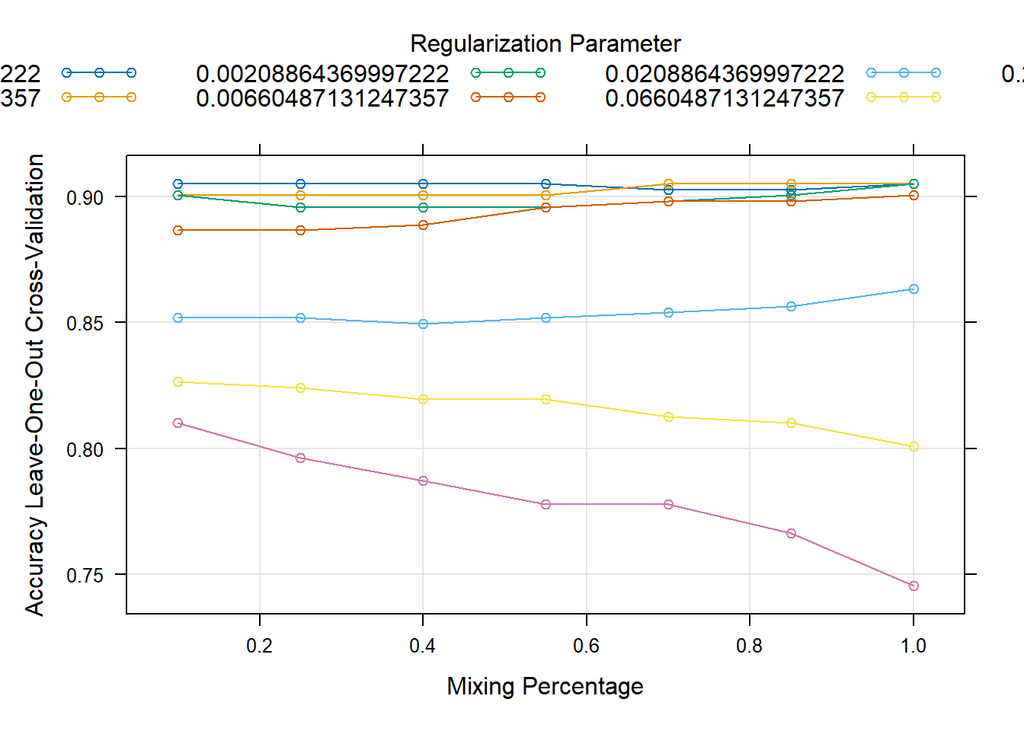

```r
logistic_n <- train(locality ~ wfr + fructose + sucrose + dry,
                    data = yacon,
                    method = "glmnet",
                    trControl = trainControl(method = "LOOCV"),
                    tuneLength=7
                    #tuneGrid=data.frame(alpha=c(0,0.5,1),lambda=c(1,0.1,0.01,0.001,0.0001,0.00001,0))
                    )
plot(logistic_n)
```

```r
print(logistic_n$bestTune)
```

```
##    alpha      lambda
## 45     1 0.002088644
```

```r
print(logistic_n$results[row.names(logistic_n$bestTune), "Accuracy"])
```

```
## [1] 0.9050926
```

## c)

### Model LDA i wartości współczynników

```r
lda_model <- lda(locality ~ wfr + fructose + sucrose + dry,
                 data = yacon)
coef(lda_model)
```

```
##                    LD1           LD2
## wfr      -4.580373e-05  0.0000421492
## fructose -7.777996e-02 -0.0582197006
## sucrose  -2.076184e-02 -0.0764710018
## dry       2.199272e-01 -0.0234264321
```

#### Wizualizacja współczynników LDA

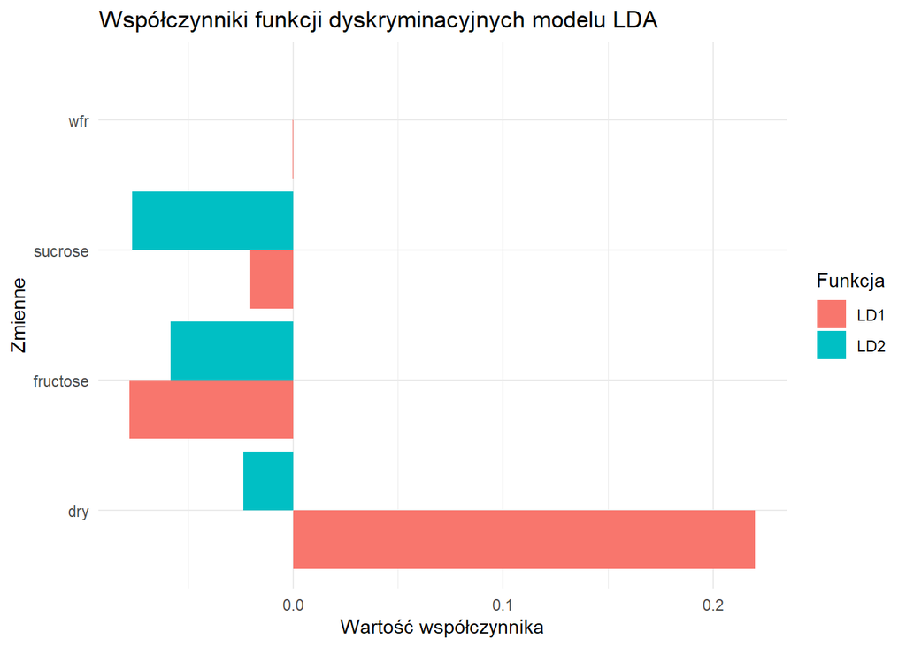

```r
# Wyciągamy współczynniki dla modelu LDA
lda_coefficients <- lda_model$scaling

# lda_coefficients to macierz, przekształcamy ją do ramki danych
lda_coefficients_df <- as.data.frame(lda_coefficients)
variables <- rownames(lda_coefficients_df)
lda_coefficients_df$Variable <- variables

# Przekształcamy do formatu długiego
lda_long <- pivot_longer(lda_coefficients_df,
                         cols = -Variable,
                         names_to = "Funkcja",
                         values_to = "Współczynniki")

# Wizualizacja
ggplot(lda_long, aes(x = Variable, y = Współczynniki, fill = Funkcja)) +
  geom_bar(stat = "identity",
           position = "dodge") +
  theme_minimal() +
  labs(title = "Współczynniki funkcji dyskryminacyjnych modelu LDA",
       x = "Zmienne",
       y = "Wartość współczynnika") +
  coord_flip()
```

#### Wizualizacja klasyfikacji

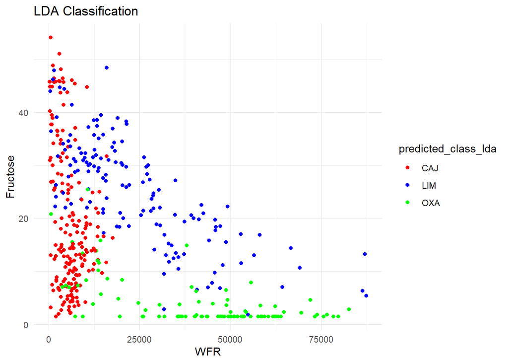

```r
lda_pred <- predict(lda_model)$class
yacon_plot <- yacon
yacon_plot$predicted_class_lda <- lda_pred

ggplot(yacon_plot, aes(x = wfr, y = fructose, color = predicted_class_lda)) +
  geom_point() +
  ggtitle("LDA Classification") +
  xlab("WFR") + ylab("Fructose") +
  theme_minimal() +
  scale_color_manual(values = c("red", "blue", "green"))
```

### Model regresji logistycznej

```r
logit_model <- glmnet(as.matrix(yacon[, -1]),
                      yacon$locality,
                      lambda = 0.0006604871,
                      alpha = 0.7,
                      family = "multinomial")
summary(logit_model)
```

```
##            Length Class  Mode
## a0         3      -none- numeric
## beta       3      -none- list
## dfmat      3      -none- numeric
## df         1      -none- numeric
## dim        2      -none- numeric
## lambda     1      -none- numeric
## dev.ratio  1      -none- numeric
## nulldev    1      -none- numeric
## npasses    1      -none- numeric
## jerr       1      -none- numeric
## offset     1      -none- logical
## classnames 3      -none- character
## grouped    1      -none- logical
## call       6      -none- call
## nobs       1      -none- numeric
```

#### Wartości współczynników

```r
coef(logit_model)
```

```
## $CAJ
## 5 x 1 sparse Matrix of class "dgCMatrix"
##                     s0
##          -0.8533920176
## wfr      -0.0004830651
## fructose  .
## sucrose   0.0295434945
## dry       0.1249934569
##
## $LIM
## 5 x 1 sparse Matrix of class "dgCMatrix"
##                     s0
##           1.0765652913
## wfr       0.0002371982
## fructose  0.1580575071
## sucrose   .
## dry      -0.5739926337
##
## $OXA
## 5 x 1 sparse Matrix of class "dgCMatrix"
##                     s0
##          -0.2231732737
## wfr       0.0001302604
## fructose -0.0840951834
## sucrose  -0.1299425006
## dry       0.0707488388
```

#### Wizualizacja współczynników

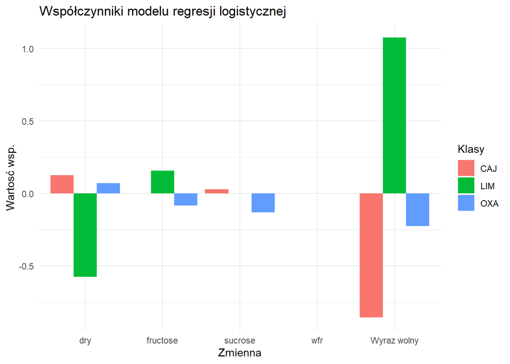

```r
# Dane współczynników z modelu
CAJ <- coef(logit_model)$CAJ
LIM <- coef(logit_model)$LIM
OXA <- coef(logit_model)$OXA

# Tworzenie ramki danych
coef_data <- data.frame(
  variable = c("Wyraz wolny", rownames(CAJ)[-1]),
  CAJ = CAJ[, "s0"],
  LIM = LIM[, "s0"],
  OXA = OXA[, "s0"]
)

# Konwersja do formatu długiego
library(tidyr)
coef_data_long <- pivot_longer(coef_data, -variable, names_to = "Klasy", values_to = "Coefficient")

# Wizualizacja
library(ggplot2)
ggplot(coef_data_long, aes(x = variable, y = Coefficient, fill = Klasy)) +
  geom_bar(stat = "identity", position = "dodge") +
  labs(title = "Współczynniki modelu regresji logistycznej",
       x = "Zmienna", y = "Wartosć wsp.") +
  theme_minimal()
```

Wysoka wartość wyrazu wolnego i niska wartość lambda wskazują na to, że wyraz wolny odgrywa kluczową rolę w modelu, a regularyzacja prowadzi do selekcji zmiennych i promuje rzadkie współczynniki, co może prowadzić do prostych granicznych decyzji modelu.

#### Wizualizacja klasyfikacji

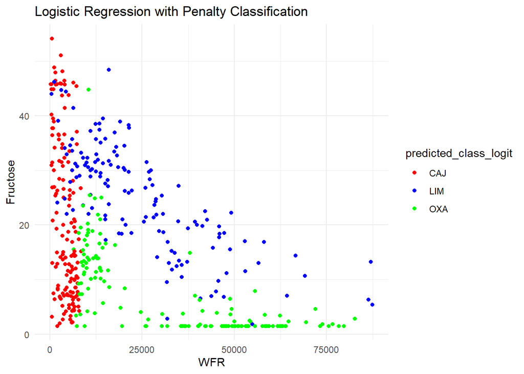

```r
# Przewidywanie klasy za pomocą modelu regresji logistycznej z karą
predictions_logit <- predict(logit_model,
                             newx = as.matrix(yacon[, -1]),
                             type = "class")
yacon_plot2 <- yacon
yacon_plot2$predicted_class_logit <- predictions_logit

# Tworzenie wykresu
ggplot(yacon_plot2, aes(x = wfr, y = fructose, color = predicted_class_logit)) +
  geom_point() +
  ggtitle("Logistic Regression with Penalty Classification") +
  xlab("WFR") + ylab("Fructose") +
  theme_minimal() +
  scale_color_manual(values = c("red", "blue", "green"))
```

### Porównanie modeli

Przeprowadzę 10-krotną i n-krotną kroswalidację dla obu modeli, używając pakietu caret do oceny prawdopodobieństw błędnej klasyfikacji.

```r
# Utworzenie indeksów podziału na dane treningowe i testowe
train_index <- createDataPartition(yacon$locality, p = 0.70, list = FALSE)

# Podział danych na zbiory treningowy i testowy
train_data <- yacon[train_index, ]
test_data <- yacon[-train_index, ]

# Modele LDA
lda_10 <- train(locality ~ wfr + fructose + sucrose + dry,
                        data = train_data,
                        method = "lda",
                        trControl = trainControl(method = "cv"),
                        tuneLength = 7)
lda_10_train_acc <- lda_10$results$Accuracy
cat("Dokładność LDA (10-krotna) na danych treningowych: ", lda_10_train_acc, "\n")
```

```
## Dokładność LDA (10-krotna) na danych treningowych:  0.8249462
```

```r
lda_n <- train(locality ~ wfr + fructose + sucrose + dry,
                        data = train_data,
                        method = "lda",
                        trControl = trainControl(method = "LOOCV"),
                        tuneLength = 7)
lda_n_train_acc <- lda_n$results$Accuracy
cat("Dokładność LDA (n-krotna) na danych treningowych: ", lda_n_train_acc, "\n")
```

```
## Dokładność LDA (n-krotna) na danych treningowych:  0.8151815
```

```r
# Modele regresji logistycznej
log_10 <- train(locality ~ wfr + fructose + sucrose + dry,
                          data = train_data,
                          method = "glmnet",
                          trControl = trainControl(method = "cv"),
                          tuneLength = 7)
log_10_train_acc <- max(log_10$results$Accuracy)
cat("Dokładność reg logistycznej (10-krotna) na danych treningowych: ", log_10_train_acc, "\n")
```

```
## Dokładność reg logistycznej (10-krotna) na danych treningowych:  0.9011828
```

```r
log_n <- train(locality ~ wfr + fructose + sucrose + dry,
                          data = train_data,
                          method = "glmnet",
                          trControl = trainControl(method = "LOOCV"),
                          tuneLength = 7)
log_n_train_acc <- max(log_n$results$Accuracy)
cat("Dokładność reg logistycznej (n-krotna) na danych treningowych: ", log_n_train_acc, "\n")
```

```
## Dokładność reg logistycznej (n-krotna) na danych treningowych:  0.9075908
```

```r
# Ocena modeli LDA na danych testowych
lda_10_pred <- predict(lda_10, newdata = test_data[-1])
lda_10_test_acc <- sum(lda_10_pred == test_data$locality)/nrow(test_data)

lda_n_pred <- predict(lda_n, newdata = test_data[-1])
lda_n_test_acc <- sum(lda_n_pred == test_data$locality)/nrow(test_data)

# Ocena modeli reg log na danych testowych
log_10_pred <- predict(log_10, newdata = test_data[-1])
log_10_test_acc <- sum(log_10_pred == test_data$locality)/nrow(test_data)

log_n_pred <- predict(log_n, newdata = test_data[-1])
log_n_test_acc <- sum(log_n_pred == test_data$locality)/nrow(test_data)

cat("LDA 10-krotna CV, dokładność na danych testowych: ", lda_10_test_acc, "\n")
```

```
## LDA 10-krotna CV, dokładność na danych testowych:  0.7674419
```

```r
cat("LDA n-krotna CV, dokładność na danych testowych: ", lda_n_test_acc, "\n")
```

```
## LDA n-krotna CV, dokładność na danych testowych:  0.7674419
```

```r
cat("Regresja logistyczna 10-krotna CV, dokładność na danych testowych: ", log_10_test_acc, "\n")
```

```
## Regresja logistyczna 10-krotna CV, dokładność na danych testowych:  0.8837209
```

```r
cat("Regresja logistyczna n-krotna CV, dokładność na danych testowych: ", log_n_test_acc, "\n")
```

```
## Regresja logistyczna n-krotna CV, dokładność na danych testowych:  0.8837209
```

Model regresji logistycznej z karą okazał się lepszy. Nie podałem parametru alpha, więc tuner użył obu LASSO i regresji grzbietowej tj. sieć elastyczną, co też mogło poprawić wynik. Z jakiegoś powodu nie ma różnicy dokładności klasyfikacji pomiędzy kroswalidacją n-krotną a 10-krotną, ale nie byłem wstanie doszukać się powdou.